# Visualización Gráficos Alluvial y Puntos

Cristóbal Ortiz

28-05-2021

### d. Gráficos Alluvial

En esta sección aprenderá a realizar gráficos “alluvial” para datos longitudinales. Este tipo de gráfico permite visualizar los cambios en la distribución de frecuencias para variables categóricas a lo largo del tiempo. Previo a la visualización de este tipo de gráfico, se siguen dos pasos necesarios para la correcta especificación de variables, a saber:

**Paso 1**: Crear una base de datos que agrupa la frecuencia de la variables de interés por otra variable de agrupación (ej. `ola`).

**Paso 2**: Crear una tabla que agrupa frecuencias en función de las categorías de respuesta tanto de la variable de interés como de la variable de agrupación (ej. `ola`)

#### d.1 Alluvial para una variable en cuatro olas: identificación con coalición política.

```r
#Paso 1
datos.grafico.d.1 <- elsoc_long %>%
    group_by(idencuesta,ola,idcoal) %>%
    summarise(n1=sum(ponderador02,na.rm=T)) %>%
    group_by(ola) %>%
    mutate(n2 = sum(n1, na.rm = TRUE), porcentaje = n1/n2)%>%
    ungroup()

#Paso 2
etiquetas.grafico.d.1 <- datos.grafico.d.1 %>%
    group_by(ola,idcoal) %>%
    summarise(porcentaje = sum(porcentaje, na.rm = TRUE)) %>%
    mutate(idencuesta = 1)
```

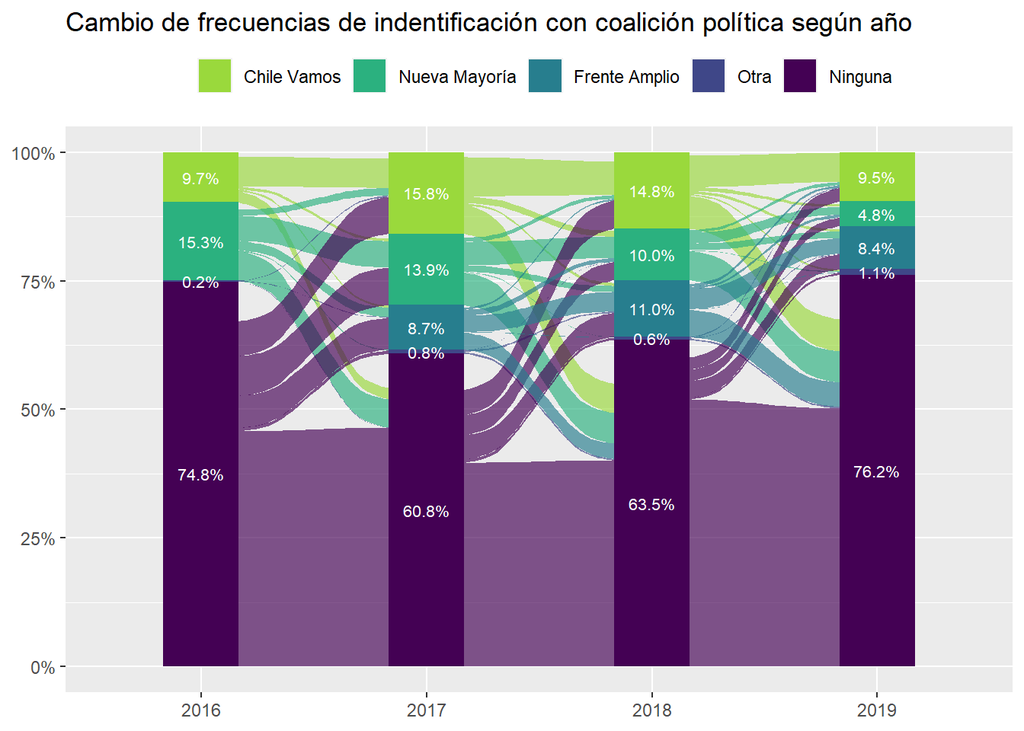

```r
d.1 <- ggplot(datos.grafico.d.1, aes(x = ola, fill = idcoal, stratum = idcoal,
                             alluvium = idencuesta, y = porcentaje)) +
    ggalluvial::geom_flow(alpha = .66) +
    ggalluvial::geom_stratum(linetype = 0) +
    scale_y_continuous(labels = scales::percent) +
    ylab(label = NULL) +
    xlab(label = NULL) +
    theme(legend.position = 'top',
          legend.title = element_blank()) +
    scale_fill_viridis_d(begin = 0, end = .85, direction = -1, option = 'viridis') +
    geom_text(data = etiquetas.grafico.d.1,
              aes(label = scales::percent(porcentaje, accuracy = .1)),
              position = position_stack(vjust = .5),
              show.legend = FALSE,
              size = 2.75,
              color = rep('white'))+
  ggtitle('Cambio de frecuencias de indentificación con coalición política según año')

d.1
```

#### d.2 Alluvial para dos olas: identificación con coalición política.

```r
#Paso 1
datos.grafico.d.2 <- elsoc_long %>%
    group_by(idencuesta,idcoal,ola) %>%
    summarise(n1 = sum(ponderador02, na.rm = TRUE)) %>%
    group_by(ola) %>%
    mutate(n2 = sum(n1, na.rm = TRUE), porcentaje = n1/n2) %>%
    ungroup()
#Paso 1.1: crear un subset que incluya la frecuencia de la variable de interés sólo para los años 2017 y 2019
datos.subset.d.2 <- droplevels(subset(datos.grafico.d.2, datos.grafico.d.2$ola == '2017' | datos.grafico.d.2$ola == '2019'))

#Paso 2
etiquetas.grafico.d.2 <- datos.subset.d.2 %>%
    group_by(idcoal,ola) %>%
    summarise(porcentaje = sum(porcentaje, na.rm = TRUE)) %>%
    mutate(idencuesta = 1)
```

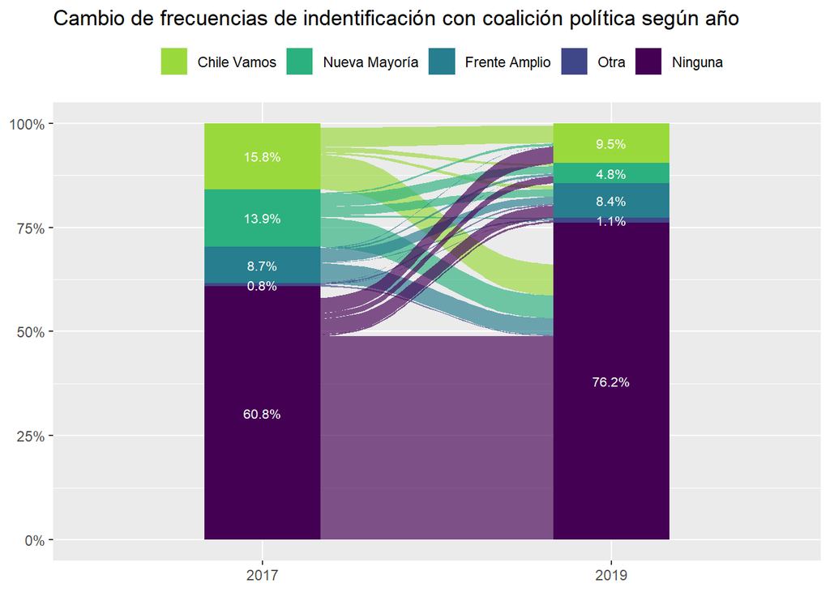

```r
d.2 <- ggplot(datos.subset.d.2, aes(x = ola, fill = idcoal, stratum = idcoal,
               alluvium = idencuesta, y = porcentaje)) +
    ggalluvial::geom_flow(alpha = .66) +
    ggalluvial::geom_stratum(linetype = 0) +
    scale_y_continuous(labels = scales::percent) +
    ylab(label = NULL) +
    xlab(label = NULL) +
    theme(legend.position = 'top',
          legend.title = element_blank()) +
    scale_fill_viridis_d(begin = 0, end = .85, direction = -1, option = 'viridis') +
    geom_text(data = etiquetas.grafico.d.2,
              aes(label = scales::percent(porcentaje, accuracy = .1)),
              position = position_stack(vjust = .5),
              show.legend = FALSE,
              size = 2.75,
              color = rep('white')) +
    ggtitle('Cambio de frecuencias de indentificación con coalición política según año')

d.2
```

#### d.3 Alluvial para dos o más categorías: situación ocupacional

```r
#Paso 1:
datos.grafico.d.3 <- elsoc_long %>%
    group_by(idencuesta,socup,sexo,ola) %>%
    summarise(n1 = sum(ponderador02, na.rm = TRUE)) %>%
    group_by(ola,sexo) %>%
    mutate(n2 = sum(n1, na.rm = TRUE), porcentaje = n1/n2) %>%
    ungroup()
#Paso 1.1: crear un subset que incluya la frecuencia de la variable de interés sólo para los años 2017 y 2019
datos.subset.d.3 <- droplevels(subset(datos.grafico.d.3, datos.grafico.d.3$ola == '2017' | datos.grafico.d.3$ola == '2019'))

#Paso 2:
etiquetas.grafico.d.3 <- datos.subset.d.3 %>%
    group_by(socup,ola, sexo) %>%
    summarise(porcentaje = sum(porcentaje, na.rm = TRUE)) %>%
    mutate(idencuesta = 1)
```

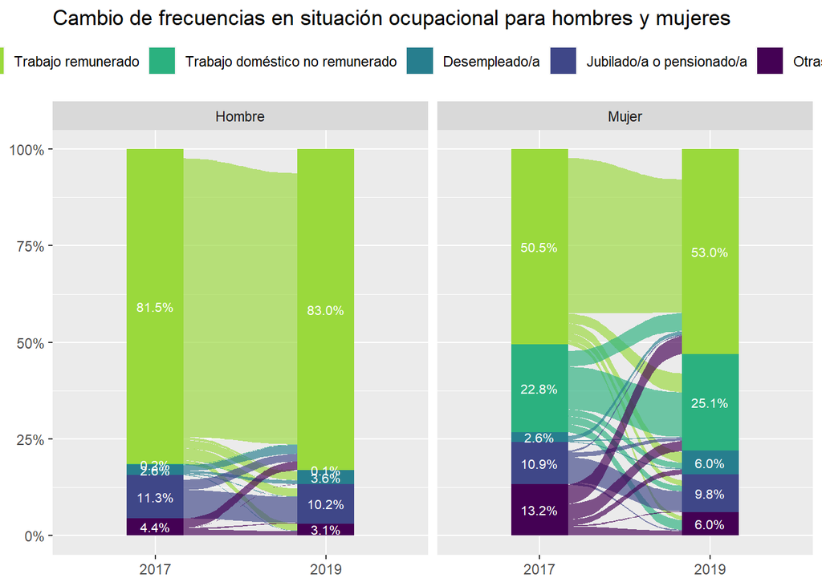

```r
d.3 <- ggplot(datos.subset.d.3, aes(x = ola, fill = socup, stratum = socup,
               alluvium = idencuesta, y = porcentaje)) +
    ggalluvial::geom_flow(alpha = .66) +
    ggalluvial::geom_stratum(linetype = 0) +
    scale_y_continuous(labels = scales::percent) +
    ylab(label = NULL) +
    xlab(label = NULL) +
    theme(legend.position = 'top',
          legend.title = element_blank()) +
    scale_fill_viridis_d(begin = 0, end = .85, direction = -1, option = 'viridis') +
    facet_wrap(.~sexo)+
    geom_text(data = etiquetas.grafico.d.3,
              aes(label = scales::percent(porcentaje, accuracy = .1)),
              position = position_stack(vjust = .5),
              show.legend = FALSE,
              size = 2.75,
              color = rep('white'))+
  ggtitle('Cambio de frecuencias en situación ocupacional para hombres y mujeres')

d.3
```

### Gráficos de lineas.

En esta sección aprenderá a realizar gráficos de lineas y puntos para datos longitudinales. Este tipo de gráfico permite visualizar los cambios de frecuencia para variables categóricas a lo largo del tiempo. Al igual que la sección anterior, se siguen dos pasos necesarios para la correcta especificación de variables, a saber:

**Paso 1**: Crear una base de datos que agrupa la frecuencia de la variables de interés por otra variable de agrupación (ej. `ola`).

**Paso 2**: Crear una tabla que agrupa frecuencias en función de las categorías de respuesta tanto de la variable de interés como de la variable de agrupación (ej. `ola`)

#### e.1 Lineas y puntos para una variable.

```r
#Paso 1:
datos.grafico.e.1 <- elsoc_long %>%
    dplyr::filter(!is.na(conf_presi)) %>%
    group_by(idencuesta,conf_presi,ola) %>%
    summarise(n1 = sum(ponderador02, na.rm = TRUE)) %>%
    group_by(ola) %>%
    mutate(n2 = sum(n1, na.rm = TRUE), porcentaje = n1/n2) %>%
    ungroup()

#Paso 2:
etiquetas.grafico.e.1 <- datos.grafico.e.1 %>%
    group_by(conf_presi,ola) %>%
    summarise(porcentaje = sum(porcentaje, na.rm = TRUE)) %>%
    mutate(idencuesta = 1)
```

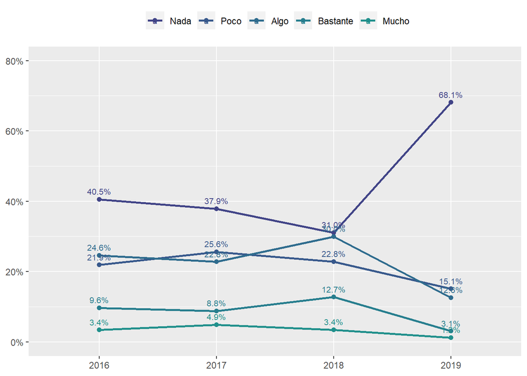

```r
e.1 <- ggplot(etiquetas.grafico.e.1,aes(y = porcentaje, x = ola, color = conf_presi, group = conf_presi,
               label = as.character(scales::percent(porcentaje, accuracy = .1)))) +
    geom_line(size = 1) +
    geom_point(size = 1.8) +
    scale_y_continuous(labels = scales::percent,
                       limits = c(0,.8)) +
    ylab(label = NULL) +
    xlab(label = NULL) +
    scale_color_viridis_d(begin = .2, end = .5, direction = 1, option = 'viridis') +
    geom_text(vjust = -0.8,
    posilinetion = position_dodge(width = .9),
    size= 2.75) +
    theme(legend.position = 'top',
          legend.title = element_blank())

e.1
```

#### e.2 Lineas y puntos para más de una variable.

```r
#Paso 1:
datos.grafico.e.2 <- elsoc_long %>%
    group_by(idencuesta,conf_presi,conf_part,conf_carb,ola) %>%
    summarise(n1 = sum(ponderador02, na.rm = TRUE)) %>%
    group_by(ola) %>%
    mutate(n2 = sum(n1, na.rm = TRUE), porcentaje = n1/n2) %>%
    ungroup()
#Paso 1.1: creamos un subset con una nueva variables llamada "conf nada", que integra todas las respuesta "Nada" a la pregunta por la confianza en tres instituciones: presidente, partidos político y carabineros.
datos.subset.e.2 <- datos.grafico.e.2 %>%
        pivot_longer(cols = starts_with('conf_'), names_to = 'conf_nada')
#Paso 1.2: renombramos los valores de la variable "conf_nada".
datos.subset.e.2$conf_nada <- factor(datos.subset.e.2$conf_nada,
                            labels = c('Confianza en el Presidente', 'Confianza en Partidos Políticos',
                                       'Confianza en Carabineros'))
#Paso 1.3: filtramos el subset a fin de dajer sólo las respuestas "Nada" de confianza en las tres instituciones mencionadas.
datos.subset.e.2a <- droplevels(subset(datos.subset.e.2, value == 'Nada'))

#Paso 2:
etiquetas.grafico.e.2a <- datos.subset.e.2a %>%
    group_by(conf_nada,ola) %>%
    summarise(porcentaje = sum(porcentaje, na.rm = TRUE)) %>%
    mutate(idencuesta = 1)
```

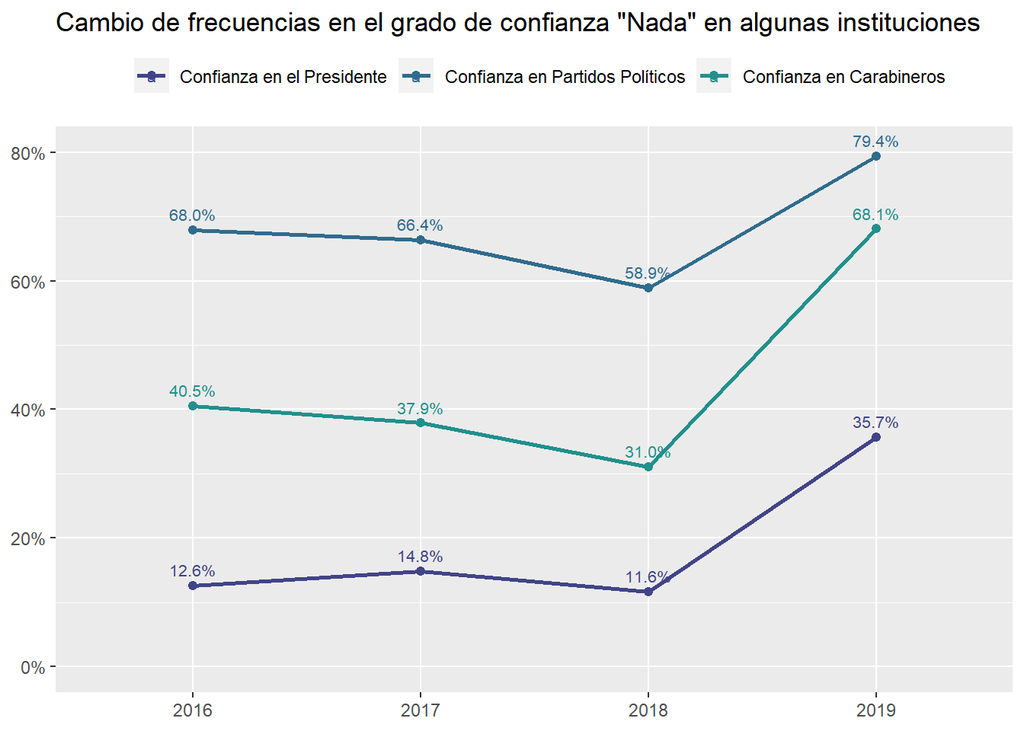

```r
e.2 <- ggplot(etiquetas.grafico.e.2a,aes(y = porcentaje, x = ola, color = conf_nada, group = conf_nada,
               label = as.character(scales::percent(porcentaje, accuracy = .1)))) +
    geom_line(size = 1) +
    geom_point(size = 1.8) +
    scale_y_continuous(labels = scales::percent,
                       limits = c(0,.8)) +
    ylab(label = NULL) +
    xlab(label = NULL) +
    scale_color_viridis_d(begin = .2, end = .5, direction = 1, option = 'viridis') +
    geom_text(vjust = -0.8,
    posilinetion = position_dodge(width = .9),
    size= 2.75) +
    theme(legend.position = 'top',
          legend.title = element_blank()) +
    ggtitle('Cambio de frecuencias en el grado de confianza "Nada" en algunas instituciones')

e.2
```

#### e.3 Lineas y puntos para una variables y más de una agrupación

```r
#Paso 1:
datos.grafico.e.3 <- elsoc_long %>%
    group_by(idencuesta,conf_presi,conf_part,conf_carb,zona,ola) %>%
    summarise(n1 = sum(ponderador02, na.rm = TRUE)) %>%
    group_by(ola,zona) %>%
    mutate(n2 = sum(n1, na.rm = TRUE), porcentaje = n1/n2) %>%
    ungroup()
#Paso 1.1
datos.subset.e.3 <- datos.grafico.e.3 %>%
        pivot_longer(cols = starts_with('conf_'), names_to = 'conf_nada')
#Paso 1.2
datos.subset.e.3$conf_nada <- factor(datos.subset.e.2$conf_nada,
                            labels = c('Confianza en el Presidente', 'Confianza en Partidos Políticos',
                                       'Confianza en Carabineros'))
#Paso 1.3
datos.subset.e.3a <- droplevels(subset(datos.subset.e.3, value == 'Nada'))

#Paso 2:
etiquetas.grafico.e.3a <- datos.subset.e.3a %>%
    group_by(conf_nada,ola,zona) %>%
    summarise(porcentaje = sum(porcentaje, na.rm = TRUE)) %>%
    mutate(idencuesta = 1)
```

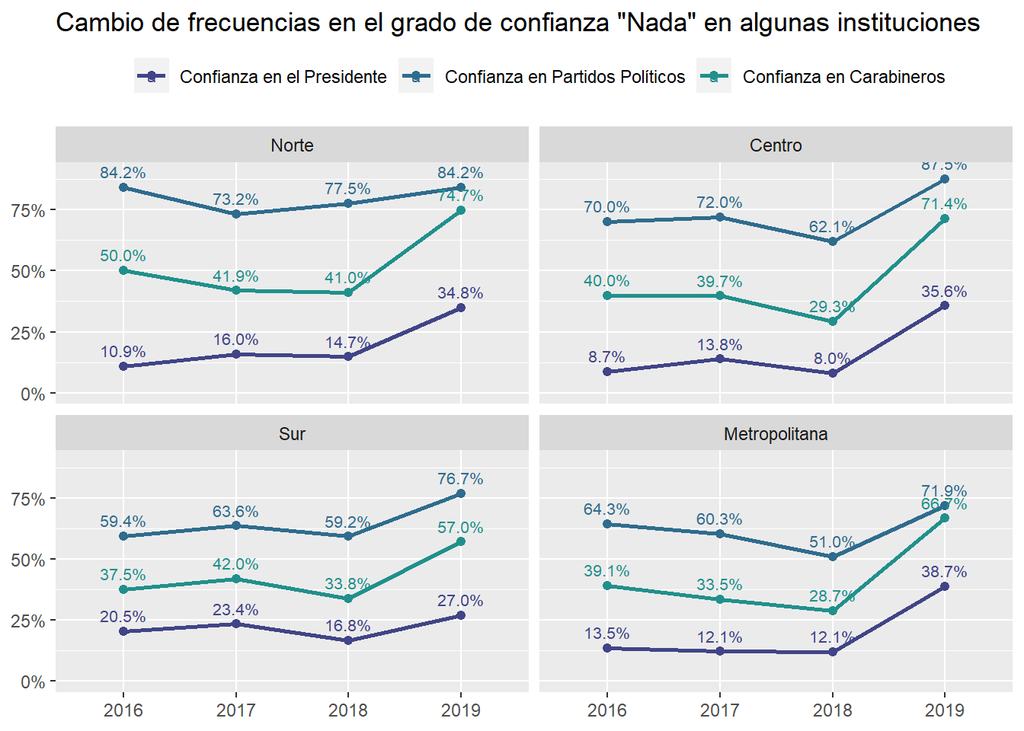

```r
e.3 <- ggplot(etiquetas.grafico.e.3a,aes(y = porcentaje, x = ola, color = conf_nada, group = conf_nada,
               label = as.character(scales::percent(porcentaje, accuracy = .1)))) +
    geom_line(size = 1) +
    geom_point(size = 1.8) +
    scale_y_continuous(labels = scales::percent,
                       limits = c(0,.9)) +
    ylab(label = NULL) +
    xlab(label = NULL) +
    scale_color_viridis_d(begin = .2, end = .5, direction = 1, option = 'viridis') +
    facet_wrap(.~zona)+
    geom_text(vjust = -0.8,
    posilinetion = position_dodge(width = .9),
    size= 2.75) +
    theme(legend.position = 'top',
          legend.title = element_blank()) +
    ggtitle('Cambio de frecuencias en el grado de confianza "Nada" en algunas instituciones')

e.3
```